# MonteCarlo 15

9 actividades; 4 expuestas a un factor común (σ_F = 0.15)

# Enunciado

Considere el proyecto cuyo cuadro de prelaciones, duraciones medias y desviaciones típicas (en semanas) se adjunta. Las actividades marcadas como *expuestas* se realizan al aire libre: su duración depende además de un factor meteorológico común $F$ de media 1 y desviación típica 0.15 (si la temporada es mala, $F > 1$ y todas ellas se alargan a la vez). La duración de una actividad expuesta es $F \cdot X$, con $X$ normal de la media y desviación del cuadro; las no expuestas son normales independientes.

1. Calcule la duración del proyecto y el camino crítico con las duraciones medias.

2. Simule 10000 réplicas suponiendo todas las duraciones independientes (ignorando $F$) y obtenga la media, la desviación típica y la probabilidad de terminar en 38 semanas o menos.

3. Repita la simulación con el factor común: en cada réplica se sortea un único valor de $F$ que multiplica a todas las actividades expuestas. Compare media, desviación típica, percentil 95 y P(T ≤ 38).

4. ¿Por qué la correlación positiva aumenta la dispersión de la duración del proyecto aunque apenas cambie la media? ¿Qué ocurre con la criticidad de las rutas?

Tabla 1: Cuadro de datos del enunciado

| activity | predecessor | duration | standard_deviation | exposed |
| --- | --- | --- | --- | --- |
| A | --- | 5 | 0.8 | sí |
| B | --- | 3 | 0.8 | no |
| C | A,B | 8 | 1.0 | no |
| D | C | 8 | 0.5 | no |
| E | C | 5 | 0.8 | no |
| F | D | 5 | 1.0 | sí |
| G | E,F | 5 | 0.8 | sí |
| H | D | 8 | 0.3 | no |
| I | F,H | 7 | 0.2 | sí |

El proyecto corresponde al lanzamiento de una aplicación móvil; las actividades son las siguientes (las duraciones del cuadro están en semanas).

Tabla 2: Descripción de las actividades

|  | Descripción |
| --- | --- |
| A | Estudio de requisitos |
| B | Diseño de la arquitectura |
| C | Diseño de interfaz y prototipo |
| D | Base de datos y modelo |
| E | API del servidor |
| F | Pantallas principales |
| G | Módulo de pagos |
| H | Notificaciones y sincronización |
| I | Pruebas de integración |

# Resolución

## Apartado 1

1. Calcule la duración del proyecto y el camino crítico con las duraciones medias.

Cálculo de los tiempos mínimos y máximos de los nodos del grafo Roy paso a paso. El primer paso muestra el grafo resuelto; a partir del siguiente se calcula desde el principio (avance con los botones):

[figure not shown]

paso 0 de 24

[figure not shown]

Figura 1: Grafo Roy con el camino crítico

Camino crítico (la ruta de mayor duración; sus actividades tienen holgura total nula):

- **A – C – D – H – I**: 5 + 8 + 8 + 8 + 7 = **36** semanas

**Duración del proyecto: 36 semanas.**

**Respuesta:** duración media del proyecto 36 semanas; camino crítico A – C – D – H – I. Actividades expuestas al factor común: A, F, G y I.

Tabla 3: Duración media de cada ruta y actividades expuestas que contiene

|  | actividades | duración media = suma | duración media | expuestas en la ruta |
| --- | --- | --- | --- | --- |
| Route_1 | A – C – D – F – G | A(5) + C(8) + D(8) + F(5) + G(5) = 31 | 31 | A, F, G |
| Route_2 | A – C – D – F – I | A(5) + C(8) + D(8) + F(5) + I(7) = 33 | 33 | A, F, I |
| Route_3 | A – C – D – H – I | A(5) + C(8) + D(8) + H(8) + I(7) = 36 | 36 | A, I |
| Route_4 | A – C – E – G | A(5) + C(8) + E(5) + G(5) = 23 | 23 | A, G |
| Route_5 | B – C – D – F – G | B(3) + C(8) + D(8) + F(5) + G(5) = 29 | 29 | F, G |
| Route_6 | B – C – D – F – I | B(3) + C(8) + D(8) + F(5) + I(7) = 31 | 31 | F, I |
| Route_7 | B – C – D – H – I | B(3) + C(8) + D(8) + H(8) + I(7) = 34 | 34 | I |
| Route_8 | B – C – E – G | B(3) + C(8) + E(5) + G(5) = 21 | 21 | G |

## Apartado 2

2. Simule 10000 réplicas suponiendo todas las duraciones independientes (ignorando $F$) y obtenga la media, la desviación típica y la probabilidad de terminar en 38 semanas o menos.

En cada réplica se sortea la duración de cada actividad con su normal (recortada en 0), se suman las duraciones a lo largo de cada ruta y la duración del proyecto es la de la ruta más larga. La probabilidad es la proporción de réplicas que no superan el plazo y el percentil 95, el valor que deja por debajo el 95 % de las réplicas ordenadas.

|  | media | desviación típica | percentil 95 | P(T ≤ 38) (%) |
| --- | --- | --- | --- | --- |
| independientes | 36.0 | 1.426 | 38.358 | 91.74 |

**Respuesta:** suponiendo independencia, media 36.000 semanas, desviación típica 1.426 y P(T ≤ 38) ≈ 9174/10000 = 0.9174 (9174 de las 10000 réplicas terminan a tiempo).

## Apartado 3

3. Repita la simulación con el factor común: en cada réplica se sortea un único valor de $F$ que multiplica a todas las actividades expuestas. Compare media, desviación típica, percentil 95 y P(T ≤ 38).

Se reutilizan las mismas duraciones normales $X$ y se multiplica cada fila (réplica) de las actividades expuestas por un valor de $F$ común a toda la fila. Así la única diferencia entre las dos simulaciones es la correlación introducida por $F$.

|  | independientes | con factor común |
| --- | --- | --- |
| media | 36.000 | 36.009 |
| desviación típica | 1.426 | 2.245 |
| percentil 95 | 38.358 | 39.792 |
| P(T ≤ 38) (%) | 91.740 | 81.540 |

Tabla 4: Correlación entre las duraciones de dos actividades expuestas

|  | independientes | con factor común |
| --- | --- | --- |
| corr(A, F) | 0.003 | 0.393 |

**Respuesta:** con el factor común la media pasa de 36.000 a 36.009 semanas (apenas cambia), la desviación típica de 1.426 a 2.245, el percentil 95 de 38.36 a 39.79 y P(T ≤ 38) de 91.74 % a 81.54 %. La correlación entre A y F pasa de 0.003 a 0.393.

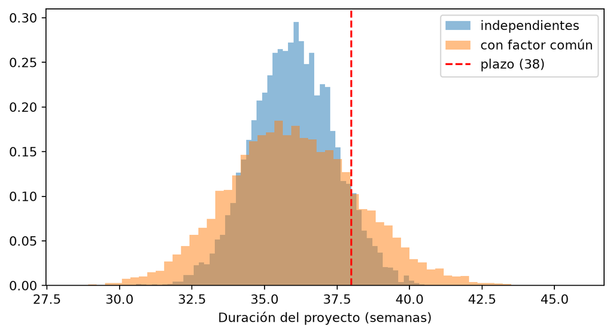

Figura 2: Distribución de la duración con y sin factor común

## Apartado 4

4. ¿Por qué la correlación positiva aumenta la dispersión de la duración del proyecto aunque apenas cambie la media? ¿Qué ocurre con la criticidad de las rutas?

La varianza de una suma de variables correlacionadas positivamente es mayor que la suma de sus varianzas (se añaden los términos $2\,\mathrm{cov}$): cuando $F$ sale alto, todas las actividades expuestas se alargan a la vez y no se compensan unas con otras. La media casi no cambia porque la de $F$ es 1, pero las colas se ensanchan.

Tabla 5: Índice de criticidad de las rutas sin y con factor común

|  | actividades | expuestas | criticidad indep. (%) | criticidad con F (%) |
| --- | --- | --- | --- | --- |
| Route_1 | A – C – D – F – G | A, F, G | 0.0 | 0.0 |
| Route_2 | A – C – D – F – I | A, F, I | 0.1 | 1.4 |
| Route_3 | A – C – D – H – I | A, I | 95.9 | 91.9 |
| Route_4 | A – C – E – G | A, G | 0.0 | 0.0 |
| Route_5 | B – C – D – F – G | F, G | 0.0 | 0.0 |
| Route_6 | B – C – D – F – I | F, I | 0.0 | 0.0 |
| Route_7 | B – C – D – H – I | I | 4.0 | 6.6 |
| Route_8 | B – C – E – G | G | 0.0 | 0.0 |

**Respuesta:** la correlación positiva hace que las actividades expuestas se retrasen (o adelanten) a la vez, sin compensarse: la desviación típica sube de 1.426 a 2.245 mientras la media apenas cambia (36.000 frente a 36.009), porque F tiene media 1. Con el factor común ganan criticidad A – C – D – F – I (+1.3 puntos) y B – C – D – H – I (+2.6 puntos); pierden criticidad A – C – D – H – I (-4.0 puntos). Lo que cuenta no es cuántas actividades expuestas tiene cada ruta, sino cuánto de su duración depende de F en comparación con la ruta crítica: cuando F sale alto se alargan más las rutas con más semanas expuestas, y cuando sale bajo, al revés. Suponer independencia, como hace el PERT clásico, es optimista en presencia de causas comunes de retraso.